# Reproducible Research: Project 2

Awadnr

January 17, 2019

# Impacts of Weather Events in the United States on Human Health and Property

##### This is an analysis of data collected and published by the U.S. National Oceanic and Atmospheric Administration. The data covers the impact and effects of weather events in the United States between 1950 and 2011. This paper will analyze the effects these weather events had on human health and property.

#### The goal of this analysis is to answer the following question:

##### 1. Across the United States, which types of events are the most harmful to human health?

##### 2. Across the United States, which type of events have the greatest economic consequences?

## Preparing Environment for Analysis

```r
library(dplyr)
library(ggplot2)
library(data.table)
library(gridExtra)
library(plyr)
```

## Data Processing

##### As a result of the large csv.bz2 file, using the readRDS function cuts time. For both goals data needs to be aggregated, summed, and sorted.

```r
#Events_Data <- read.csv("repdata_data_StormData.csv.bz2")
#saveRDS(Events_Data, "Events_Data.RDS")
Events_Data <- readRDS("Events_Data.RDS")
```

```r
# Fatalities and Injuries
# Extracting only columns needed for analysis to increase processing speed.

We_Events<- Events_Data[c("EVTYPE", "FATALITIES", "INJURIES",
         "PROPDMG", "PROPDMGEXP", "CROPDMG", "CROPDMGEXP")]

# Summarizing injury and fatality data for human health impact analysis

Injuries <- aggregate(INJURIES~EVTYPE, We_Events, sum)
Fatalities <- aggregate(FATALITIES~EVTYPE, We_Events, sum)

# Ordering events by most hazardous to human health

Fatal_Num <- Fatalities[Fatalities$FATALITIES > 0, ]
Fatal_Rank <- Fatal_Num[order(Fatal_Num$FATALITIES,
              decreasing = TRUE), ]

Injuries_Num <- Injuries[Injuries$INJURIES > 0, ]
Injuries_Rank <- Injuries_Num[order(Injuries_Num$INJURIES,
                 decreasing = TRUE), ]
```

```r
# Property and Crop Damage
# Assigning factors to numeric values for calculation of damage by event type.

We_Events$PROPDMGEXP2 <- mapvalues(We_Events$PROPDMGEXP, from = c("K", "M","", "B",
                    "m", "+", "0", "5", "6", "?", "4", "2", "3", "h", "7",
                    "H", "-", "1", "8"), to = c(10^3, 10^6, 1, 10^9, 10^6,
                    0,1,10^5, 10^6, 0, 10^4, 10^2, 10^3, 10^2, 10^7, 10^2,
                    0, 10, 10^8))
We_Events$PROPDMGEXP2 <- as.numeric(as.character(We_Events$PROPDMGEXP2))

We_Events$CROPDMGEXP2 <- mapvalues(We_Events$CROPDMGEXP, from = c("","M", "K", "m",
                    "B", "?", "0", "k","2"), to = c(1,10^6, 10^3, 10^6,
                    10^9, 0, 1, 10^3, 10^2))
We_Events$CROPDMGEXP2 <- as.numeric(as.character(We_Events$CROPDMGEXP2))

# Calulate total property and crop damage

We_Events$PROP_TOT <- (We_Events$PROPDMG * We_Events$PROPDMGEXP2)
We_Events$CROP_TOT <- (We_Events$CROPDMG * We_Events$CROPDMGEXP2)
We_Events$Exp_Total <- We_Events$PROP_TOT + We_Events$CROP_TOT
```

## Results

##### By taking the top 5 most dangerous and damaging events and plotting the result we can quickly see which events cause the most concern.

```r
# Fatalities and Injuries
# Grabbing top 5 events most hazardous to human health

Injuries_5 <- head(Injuries_Rank, n = 5)
Fatal_5 <- head(Fatal_Rank, n = 5)

Injuries_5
```

```
##             EVTYPE INJURIES
## 834        TORNADO    91346
## 856      TSTM WIND     6957
## 170          FLOOD     6789
## 130 EXCESSIVE HEAT     6525
## 464      LIGHTNING     5230
```

```r
Fatal_5
```

```
##             EVTYPE FATALITIES
## 834        TORNADO       5633
## 130 EXCESSIVE HEAT       1903
## 153    FLASH FLOOD        978
## 275           HEAT        937
## 464      LIGHTNING        816
```

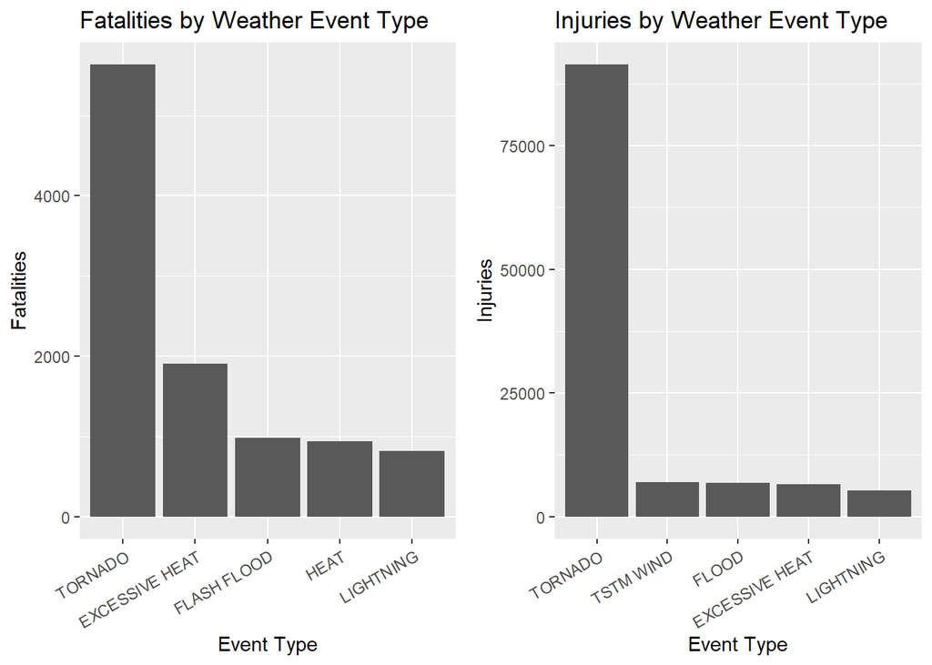

```r
# Securing list orders in Fatality and Injury plots by ordering levels

Fatal_5$EVTYPE <- factor(Fatal_5$EVTYPE,
                  levels = Fatal_5$EVTYPE[order(-Fatal_5$FATALITIES)])
Injuries_5$EVTYPE <- factor(Injuries_5$EVTYPE,
                     levels = Injuries_5$EVTYPE[order(-Injuries_5$INJURIES)])

# Fatality numbers by event type

Fatality_plot <- ggplot(data = Fatal_5, aes(x = EVTYPE, y = FATALITIES)) +
                   geom_bar(stat="identity") +
                   ggtitle(label = "Fatalities by Weather Event Type") +
                   labs(x = "Event Type", y = "Fatalities") +
                   theme(axis.text.x = element_text(angle = 30, hjust = 1))

# Injury numbers by event type

Injury_plot<- ggplot(data = Injuries_5, aes(x = EVTYPE, y = INJURIES)) +
                geom_bar(stat="identity") +
                ggtitle(label = "Injuries by Weather Event Type") +
                labs(x = "Event Type", y = "Injuries") +
                theme(axis.text.x = element_text(angle = 30, hjust = 1))
grid.arrange(Fatality_plot, Injury_plot, ncol = 2)
```

```r
# Property and Crop Damage
# Aggregate damage by event type and grab events with the 5 highest economic consequences

Gr_Econ_Event <- aggregate(We_Events$Exp_Total, by = list(We_Events$EVTYPE),
                 FUN = sum)

Gr_Econ_Event <- head(Gr_Econ_Event[order(Gr_Econ_Event$x,
                decreasing = TRUE),], n=5)
Gr_Econ_Event
```

```
##               Group.1            x
## 170             FLOOD 150319678257
## 411 HURRICANE/TYPHOON  71913712800
## 834           TORNADO  57362333887
## 670       STORM SURGE  43323541000
## 244              HAIL  18761221986
```

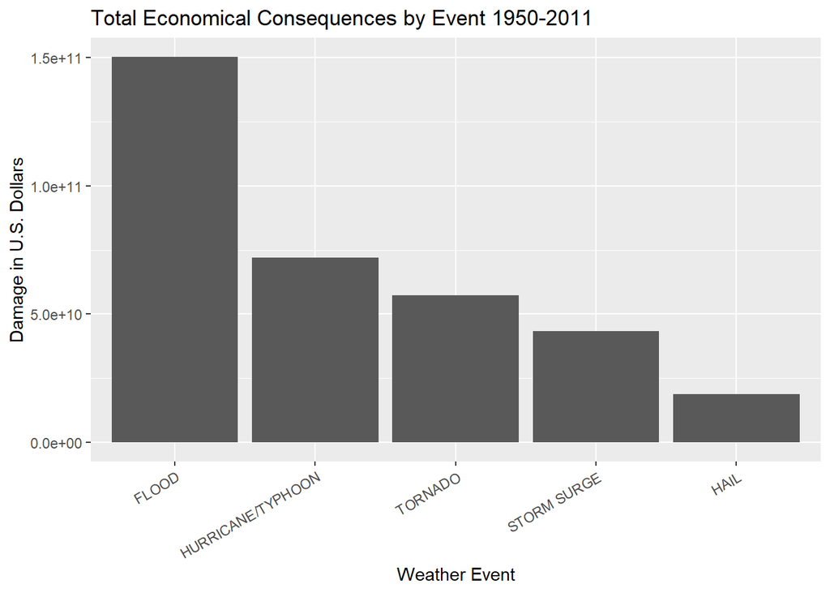

```r
# Plotting property and crop damage by event type

Damage_plot <- ggplot(Gr_Econ_Event, aes(x = reorder(Group.1, -x), y = x)) +
               geom_bar(stat = "identity") +
               labs( y= "Damage in U.S. Dollars", x = "Weather Event") +
               ggtitle ("Total Economical Consequences by Event 1950-2011") +
               theme(axis.text.x = element_text(angle = 30, hjust = 1))
Damage_plot
```

## Conclusion

##### The analysis conducted shows that Tornados are by-far the most harmful to human life and health, far exceeding the runner ups of heat, floods, lightning and wind.

##### Tornados ae also in the top five most damging weather events to property and crops but are exceeded in damage amount by hurricanes and Floods. Flooding causes almost double the amount of damage done by the runner up in this catagory : hurricanes.